# Copy of NLP_Project_Full_Code-1

## **Word Embeddings**

### Word2Vec

```python
# Create a list of all words in our data
words_list = [item.split(" ") for item in stock['News']]
```

```python
# Create an instance of Word2Vec
vec_size = 300
model_W2V = Word2Vec(words_list, vector_size = vec_size, min_count = 1, window=5, workers = 6)
```

```python
# Check the size of the vocabulary
print("Length of the vocabulary is", len(list(model_W2V.wv.key_to_index)))
```

```
Length of the vocabulary is 4682
```

Let's check out a few word embeddings obtained using the model.

```python
# Check the word embedding of a random word
word = "bull"
model_W2V.wv[word]
```

```
array([ 3.19297705e-03,  2.33991700e-03, -1.48362189e-03,  5.04702097e-04,
       -2.47541396e-03, -2.62108236e-03,  4.56363475e-03,  8.76024459e-03,
        3.40464292e-03,  4.42189426e-04,  3.93158942e-03, -1.36704941e-03,
       -1.95091579e-03, -3.41390725e-04, -3.49134509e-03, -2.21958710e-03,
        2.63200986e-04,  2.11971835e-03,  2.13373033e-03,  1.44049665e-03,
        1.56193564e-03, -2.74901715e-04,  1.82003248e-04,  9.61117330e-04,
       -1.88924221e-03, -7.03792262e-04, -2.06524460e-03,  4.49362095e-04,
       -4.69169999e-03, -3.57783679e-03,  2.02330085e-03,  3.95326730e-04,
       -7.52692693e-04,  2.37029837e-03, -7.37286537e-05,  3.77952633e-03,
        3.15941201e-04, -1.41973735e-03, -7.28519881e-05, -1.15716981e-03,
        5.09673846e-04,  5.83016845e-05, -2.57375010e-04, -1.53691054e-03,
        4.31919005e-03,  3.35610542e-03, -1.29249250e-03,  3.19467881e-03,
       -3.56525206e-03,  2.41101859e-03,  4.08144621e-03,  2.42257753e-04,
        1.22558605e-03,  1.11017842e-03,  1.15562335e-03, -5.03270654e-04,
        4.90416249e-04,  1.91515195e-03, -2.16481695e-03, -1.05691713e-03,
        9.87276551e-04, -3.11561534e-03,  4.20928758e-04,  2.32284353e-03,
       -1.63361919e-03, -9.51854090e-05, -1.16926269e-03, -3.70295049e-04,
       -2.58188538e-05, -8.28753866e-04,  1.01294869e-03,  9.42264916e-04,
       -6.55976764e-04, -7.64648838e-04,  3.28331022e-03,  3.14938044e-03,
        5.06498502e-04, -2.19378620e-03, -2.80176918e-03,  2.25002156e-03,
       -4.62212134e-04, -4.30890406e-03,  1.97129184e-03,  6.69631222e-03,
        3.60103184e-03, -2.53497530e-03, -3.44829774e-03,  1.09773653e-03,
        6.15041796e-03, -1.57000695e-03,  2.22864817e-03, -2.84848036e-03,
       -9.93254711e-04, -1.53940881e-03,  4.82279249e-03,  5.72218327e-04,
        2.18104245e-03, -9.30043578e-04, -3.52405477e-03,  4.87699546e-03,
        3.24495719e-04, -2.11728457e-03,  2.77635013e-03, -2.30523059e-03,
        1.69567997e-03, -1.45871099e-03, -2.96515413e-04,  3.66260181e-03,
        4.35300870e-04, -2.15759920e-03,  5.31732949e-05, -5.66405361e-04,
       -1.49813574e-03,  3.96230258e-03,  1.44269597e-03,  1.45658874e-03,
        2.42742593e-03,  1.17204769e-03,  6.78952783e-03, -4.76084417e-03,
        1.14725484e-03, -1.17383350e-03,  5.51809964e-04,  5.09134436e-04,
       -2.92348815e-03, -1.70770288e-03, -1.23265944e-03, -3.32546537e-03,
        2.95031350e-03,  4.18652175e-03,  1.74795871e-03,  4.64217924e-03,
        6.04970322e-04, -6.18873304e-03,  1.78089525e-04,  4.40453831e-03,
        2.19711452e-03, -4.08632262e-03, -7.60268769e-04, -1.00299285e-03,
        1.30241632e-03, -4.56364825e-03, -7.21526740e-04,  3.98018723e-03,
        4.61218227e-03, -3.56412958e-03, -8.72885226e-04, -8.40443070e-04,
        4.41133365e-04, -4.20954311e-03,  2.06670794e-03, -2.64981948e-03,
        3.85169405e-04, -1.90655596e-03,  2.25950358e-03,  4.04502545e-03,
       -5.34636760e-03,  2.05251548e-04, -3.38690123e-03,  4.88293241e-04,
```

[output cut: 21 more lines]

```
        4.97634173e-04, -3.01854825e-03,  1.85413181e-03,  5.55633218e-04,
       -1.84923515e-03, -6.12262869e-04,  6.07933267e-04,  3.86591419e-05,
        2.70703575e-03,  3.95190174e-04, -1.23819627e-03, -2.56029912e-03,
        1.13119977e-03,  1.36855501e-03, -4.56128037e-03, -9.51682683e-04,
        6.42234809e-04,  1.56806561e-03, -7.72495347e-04, -5.61639201e-03,
       -5.07529126e-03, -1.60029609e-04,  4.08961205e-03,  1.34660373e-03,
       -3.36622726e-03,  6.51084934e-04,  1.62441668e-03,  2.85896567e-05,
        3.38708796e-03, -5.52320038e-04,  5.78282122e-03,  1.27907912e-03,
        3.83620500e-03, -2.07650405e-03, -1.43613946e-03,  1.10424787e-03,
        3.14491894e-03, -1.71627529e-04,  5.34559367e-04,  2.72785476e-03,
        2.51691163e-05, -1.97490561e-03, -5.42993005e-03,  4.48116800e-03,
        1.52795739e-03,  3.36136669e-03,  2.59047584e-03,  4.48090490e-03,
        4.80634655e-04,  1.65469688e-03,  1.71453354e-03,  2.87970318e-03,
        1.64572895e-03,  2.29628829e-04, -9.18005244e-05, -2.96996161e-03],
      dtype=float32)
```

```python
# Check the word embedding of a random word
word = "sector"
model_W2V.wv[word]
```

```
array([ 8.64594942e-04,  8.07034411e-03,  2.70883483e-03,  5.18024527e-03,
       -6.00532629e-04, -1.19905993e-02,  9.83188208e-03,  2.11384930e-02,
        3.17560323e-03, -2.68573873e-03, -7.66561367e-04, -5.07004419e-03,
       -3.37545061e-04,  2.89737526e-03, -6.59802556e-03, -4.08125017e-03,
        2.24459800e-03, -1.69874285e-03, -1.88604929e-03, -3.68631619e-04,
       -1.97382784e-03,  2.76184757e-03,  6.27774419e-03,  1.14172231e-03,
        5.05977962e-03,  1.89698441e-03, -1.09201502e-02,  4.17645602e-03,
       -3.27687664e-03, -1.16528124e-02,  6.40275073e-04, -5.80767449e-03,
       -3.40907340e-04, -1.98779302e-03,  1.72689732e-03,  1.34586962e-03,
        2.81013479e-03, -9.93184093e-03,  7.50526669e-04, -4.88153193e-03,
       -4.22411319e-03,  1.91584695e-03, -6.56509947e-04, -2.63537886e-03,
        4.29762201e-03,  1.17808348e-02, -1.31953578e-03,  5.06528653e-03,
       -2.77087139e-03,  7.26004550e-03,  2.12853635e-03,  4.18579997e-03,
       -5.36816521e-03,  3.67817306e-03, -2.29315856e-03,  7.32110394e-03,
        3.98018351e-03,  2.34065671e-03,  1.24437734e-03, -2.64553633e-03,
       -8.45138333e-04, -4.58867569e-03, -1.10443786e-03,  3.57879465e-03,
       -4.44737845e-04,  2.61991663e-04, -3.51580372e-03,  6.66833390e-03,
       -7.47756753e-03,  1.09160098e-03, -3.02000646e-03,  8.74867197e-03,
        8.92452244e-03, -4.93412651e-03, -1.65557652e-03,  1.13531691e-03,
       -6.42849319e-03, -1.84507784e-03, -2.73336959e-03,  5.32314042e-03,
       -5.62367355e-03, -8.86803214e-03,  2.03351700e-03,  1.21001769e-02,
        4.97515174e-03,  1.00854260e-03,  3.71260365e-04,  3.69596528e-04,
        1.23537332e-02,  7.58409547e-03,  4.57142387e-03, -5.89752244e-03,
        5.14575979e-03,  9.97257768e-04,  7.61828478e-03,  5.69130573e-03,
        5.70578920e-03, -2.55721714e-03, -7.05961417e-03,  3.96428257e-03,
        1.67638017e-03,  1.76147686e-03,  5.76198846e-03,  6.57128228e-04,
        9.37473029e-04, -3.60185211e-03, -1.62717642e-03,  4.52502444e-03,
       -4.13813768e-03, -6.59401267e-05, -7.07893120e-03, -2.87040952e-03,
        1.74448383e-03,  9.25184414e-03, -5.76922321e-04,  3.50700575e-03,
        9.45120933e-04, -1.58727588e-03,  1.07064079e-02, -8.48165154e-03,
        4.91866516e-03,  2.67344364e-03,  6.81027584e-03, -7.82448507e-04,
       -3.68775032e-03,  6.43243827e-03,  3.05377267e-04, -3.75848101e-03,
        1.19477510e-03,  6.53625466e-03,  7.62550684e-04,  1.14253005e-02,
        2.48527224e-03, -9.23340488e-03,  6.86041452e-03,  3.79395299e-03,
        6.66491804e-04, -2.42657959e-03, -1.04743382e-02, -1.17129171e-02,
        6.16019871e-03, -1.08469790e-02, -4.08036076e-03,  5.13067516e-03,
        5.05978195e-03, -2.43655057e-03, -9.35298391e-03, -1.10942964e-03,
        2.43740040e-03, -9.72411409e-03,  3.22754425e-03, -1.51907345e-02,
       -9.06605157e-04, -5.49561949e-03,  1.33523915e-03,  4.00313549e-03,
       -1.16213327e-02, -4.99565620e-03, -3.28423409e-03,  9.56837833e-03,
```

[output cut: 21 more lines]

```
       -3.24581773e-03, -9.88413300e-03, -2.76285363e-03,  1.10602996e-03,
        1.77689898e-03,  7.94007070e-03,  5.92257595e-03,  1.71533658e-03,
        2.81819841e-03, -4.65893885e-04, -7.78483553e-03, -6.91845315e-03,
        8.49407911e-03,  1.08199916e-03, -9.31450166e-03, -6.12599077e-03,
        5.12980856e-04,  4.29020077e-03,  7.19101401e-03, -1.47841088e-02,
       -8.95342976e-03,  8.62951507e-04,  2.39292206e-03,  6.22430537e-03,
       -1.08609954e-02,  4.65995306e-03, -1.80767954e-03,  3.29591474e-03,
        4.63997433e-03, -2.32645194e-03,  6.67436421e-03,  4.20002081e-03,
        3.45809874e-03, -4.64824901e-04, -9.78392083e-03,  8.33154481e-04,
        5.55889867e-03,  3.58520658e-03,  9.95728071e-04,  9.88336629e-04,
       -6.22627093e-03, -3.60495690e-03, -9.40017682e-03,  8.05270299e-03,
        4.02538572e-03,  8.31943937e-03,  6.41234312e-03,  1.09986020e-02,
        1.04157487e-02, -2.20818026e-03,  9.72288754e-03,  1.41183399e-02,
        3.95578827e-04, -3.11122369e-03,  6.49249181e-03, -6.80709304e-03],
      dtype=float32)
```

```python
# Retrieve the words present in the Word2Vec model's vocabulary
words = list(model_W2V.wv.key_to_index.keys())

# Retrieve word vectors for all the words present in the model's vocabulary
wvs = model_W2V.wv[words].tolist()

# Create a dictionary of words and their corresponding vectors
word_vector_dict = dict(zip(words, wvs))
```

```python
def average_vectorizer_Word2Vec(doc):
    # Initialize a feature vector for the sentence
    feature_vector = np.zeros((vec_size,), dtype="float64")

    # Create a list of words in the sentence that are present in the model vocabulary
    words_in_vocab = [word for word in doc.split() if word in words]

    # Add the vector representations of the words
    for word in words_in_vocab:
        feature_vector += np.array(word_vector_dict[word])

    # Divide by the number of words to get the average vector
    if len(words_in_vocab) != 0:
        feature_vector /= len(words_in_vocab)

    return feature_vector
```

```python
# Create a dataframe of the vectorized documents
start = time.time()

X_train_wv = pd.DataFrame(X_train["News"].apply(average_vectorizer_Word2Vec).tolist(), columns=['Feature '+str(i) for i in range(vec_size)])
X_val_wv = pd.DataFrame(X_val["News"].apply(average_vectorizer_Word2Vec).tolist(), columns=['Feature '+str(i) for i in range(vec_size)])
X_test_wv = pd.DataFrame(X_test["News"].apply(average_vectorizer_Word2Vec).tolist(), columns=['Feature '+str(i) for i in range(vec_size)])

end = time.time()
print('Time taken ', (end-start))
```

```
Time taken  0.462965726852417
```

```python
print(X_train_wv.shape, X_val_wv.shape, X_test_wv.shape)
```

```
(286, 300) (21, 300) (42, 300)
```

- Each news content has been converted to a 300-dimensional vector.

```python
X_train_wv
```

|  | Feature 0 | Feature 1 | Feature 2 | Feature 3 | Feature 4 | Feature 5 | Feature 6 | Feature 7 | Feature 8 | Feature 9 | ... | Feature 290 | Feature 291 | Feature 292 | Feature 293 | Feature 294 | Feature 295 | Feature 296 | Feature 297 | Feature 298 | Feature 299 |
| --- | --- | --- | --- | --- | --- | --- | --- | --- | --- | --- | --- | --- | --- | --- | --- | --- | --- | --- | --- | --- | --- |
| 0 | 0.000662 | 0.038748 | 0.002188 | 0.025257 | -0.005317 | -0.044256 | 0.031878 | 0.077313 | 0.005899 | -0.011468 | ... | 0.017757 | 0.041869 | 0.032160 | -0.002536 | 0.040786 | 0.054787 | 0.004463 | -0.021201 | 0.024848 | -0.025509 |
| 1 | 0.001500 | 0.037610 | 0.001506 | 0.024197 | -0.005689 | -0.042395 | 0.030921 | 0.073763 | 0.005775 | -0.011203 | ... | 0.017111 | 0.039839 | 0.031509 | -0.002470 | 0.038779 | 0.052445 | 0.004721 | -0.019950 | 0.023261 | -0.024852 |
| 2 | 0.000600 | 0.034827 | 0.001702 | 0.023069 | -0.005364 | -0.039333 | 0.028192 | 0.068828 | 0.005505 | -0.010228 | ... | 0.015189 | 0.037480 | 0.029315 | -0.002684 | 0.036276 | 0.049249 | 0.004131 | -0.018910 | 0.022389 | -0.023090 |
| 3 | 0.000625 | 0.039913 | 0.002045 | 0.025790 | -0.005093 | -0.045422 | 0.032635 | 0.079729 | 0.006779 | -0.011738 | ... | 0.018453 | 0.043075 | 0.033366 | -0.002726 | 0.042054 | 0.056626 | 0.004261 | -0.021902 | 0.024941 | -0.026159 |
| 4 | 0.000284 | 0.037571 | 0.002528 | 0.024942 | -0.005501 | -0.043063 | 0.030796 | 0.075014 | 0.005913 | -0.011091 | ... | 0.017115 | 0.040373 | 0.031713 | -0.002518 | 0.039619 | 0.053273 | 0.004302 | -0.020569 | 0.024169 | -0.025210 |
| ... | ... | ... | ... | ... | ... | ... | ... | ... | ... | ... | ... | ... | ... | ... | ... | ... | ... | ... | ... | ... | ... |
| 281 | 0.000559 | 0.032954 | 0.002540 | 0.022228 | -0.004653 | -0.039123 | 0.027843 | 0.067512 | 0.005936 | -0.010164 | ... | 0.014650 | 0.036688 | 0.028522 | -0.002319 | 0.035578 | 0.048110 | 0.003409 | -0.018940 | 0.021429 | -0.022271 |
| 282 | 0.001209 | 0.034152 | 0.002317 | 0.022461 | -0.004687 | -0.039244 | 0.028059 | 0.068791 | 0.005630 | -0.010514 | ... | 0.015566 | 0.038061 | 0.029134 | -0.002315 | 0.036121 | 0.048534 | 0.003911 | -0.018605 | 0.022314 | -0.022451 |
| 283 | 0.000685 | 0.031458 | 0.001607 | 0.020096 | -0.004816 | -0.036482 | 0.025501 | 0.063009 | 0.004787 | -0.010060 | ... | 0.014126 | 0.034142 | 0.026807 | -0.002582 | 0.032328 | 0.044615 | 0.003748 | -0.018014 | 0.020293 | -0.021002 |
| 284 | 0.000707 | 0.028939 | 0.002051 | 0.019040 | -0.004524 | -0.033566 | 0.024172 | 0.057935 | 0.005113 | -0.008782 | ... | 0.012852 | 0.030920 | 0.024794 | -0.002066 | 0.030690 | 0.040283 | 0.003551 | -0.015890 | 0.018384 | -0.019529 |
| 285 | 0.000868 | 0.038880 | 0.001982 | 0.025718 | -0.005427 | -0.044661 | 0.032445 | 0.077906 | 0.006021 | -0.011710 | ... | 0.017275 | 0.041957 | 0.032816 | -0.002811 | 0.040788 | 0.054727 | 0.004705 | -0.021334 | 0.024967 | -0.026105 |

286 rows × 300 columns

### GloVe

```python
# Load the Stanford GloVe model
filename = '/content/drive/MyDrive/Python Course/glove.6B.100d.txt.word2vec'
glove_model = KeyedVectors.load_word2vec_format(filename, binary=False)
```

```python
# Check the size of the vocabulary
print("Length of the vocabulary is", len(glove_model.index_to_key))
```

```
Length of the vocabulary is 400000
```

Let's check out a few word embeddings.

```python
# Check the word embedding of a random word
word = "bull"
glove_model[word]
```

```
array([ 0.70637  , -0.17369  , -0.026774 , -0.59136  , -0.2632   ,
        0.012874 , -0.070645 , -0.35611  , -0.26435  , -1.8096   ,
       -0.48133  ,  0.56868  ,  0.42267  , -0.028756 , -0.2869   ,
        0.90847  ,  0.20179  ,  0.11058  ,  0.24963  ,  0.35501  ,
        0.38711  , -0.034597 , -0.624    ,  0.31495  ,  0.22922  ,
        0.39614  , -0.91846  ,  0.22049  ,  0.090879 ,  0.38784  ,
        0.0051792, -0.45197  ,  0.12013  ,  0.35548  ,  0.394    ,
        0.28246  , -0.39339  ,  0.58375  ,  1.0209   ,  0.47056  ,
        0.49017  , -0.53704  ,  0.12029  , -0.56243  , -0.40222  ,
        0.057731 ,  0.54687  , -0.57941  , -0.16338  , -0.50474  ,
       -0.60938  , -0.12558  , -0.75645  ,  0.43425  , -0.31549  ,
       -1.8021   , -1.0862   ,  0.75962  ,  0.47356  , -0.17434  ,
        0.79246  ,  0.084475 ,  0.053941 ,  0.76035  ,  0.56468  ,
        0.53936  , -0.14723  , -0.45047  ,  0.47358  ,  0.19137  ,
       -0.010771 , -0.22077  , -0.40858  ,  0.17004  , -0.40531  ,
       -0.26623  , -0.085666 , -0.13097  , -0.82995  , -0.58159  ,
        0.90023  , -0.23267  , -0.50252  ,  0.62379  , -0.049416 ,
        0.045887 , -0.54708  , -0.53138  ,  0.74748  ,  0.056668 ,
       -0.78229  , -0.4695   ,  0.020015 ,  0.48908  , -0.173    ,
       -0.42599  , -0.71666  , -0.0023154,  0.11153  , -0.17542  ],
      dtype=float32)
```

```python
# Check the word embedding of a random word
word = "sector"
glove_model[word]
```

```
array([-0.21739 ,  0.33174 , -0.22599 ,  0.42469 , -0.11928 , -1.3952  ,
       -0.61638 ,  0.16532 ,  0.70989 , -0.061456,  0.26858 , -0.72516 ,
        0.22991 , -0.16301 , -0.34453 , -0.33406 ,  0.05817 , -0.1685  ,
        0.1737  ,  0.51392 ,  0.44451 ,  0.064872, -0.052846,  0.25639 ,
       -0.66442 , -0.94907 ,  0.12682 ,  0.025997, -0.68997 , -0.037575,
       -0.27894 ,  0.011533,  0.1049  , -0.71057 , -0.32381 , -0.052246,
        0.24593 ,  0.13478 , -0.44602 , -0.22216 ,  0.029992, -0.8204  ,
        0.048683,  0.43101 ,  0.43145 , -0.41937 ,  0.195   ,  1.001   ,
       -0.40675 , -1.1748  , -1.0851  ,  0.52076 , -0.46837 ,  1.1032  ,
       -0.16561 , -1.341   , -0.21264 , -0.6057  ,  1.995   ,  0.59525 ,
        0.24307 , -0.75293 , -0.59347 ,  0.058302,  0.12146 ,  0.64771 ,
        0.27476 , -0.47577 ,  1.2488  ,  0.031337,  0.73221 , -0.015229,
       -0.64309 , -0.45713 ,  0.30611 , -0.24862 , -0.21978 ,  0.46051 ,
       -0.57377 , -0.2312  ,  1.14    ,  0.48758 , -0.5097  ,  0.10044 ,
       -1.2822  , -0.36468 , -0.15005 , -0.56855 ,  0.075334, -0.54233 ,
        0.52299 , -0.21303 , -0.4815  , -0.31234 , -0.27282 ,  1.4918  ,
        0.55346 , -0.30467 ,  0.8394  ,  0.27971 ], dtype=float32)
```

```python
# Retrieve the words present in the GloVe model's vocabulary
glove_words = glove_model.index_to_key

# Create a dictionary of words and their corresponding vectors
glove_word_vector_dict = dict(zip(glove_model.index_to_key,list(glove_model.vectors)))
```

```python
vec_size=100
```

```python
def average_vectorizer_GloVe(doc):
    # Initialize a feature vector for the sentence
    feature_vector = np.zeros((vec_size,), dtype="float64")

    # Create a list of words in the sentence that are present in the model vocabulary
    words_in_vocab = [word for word in doc.split() if word in glove_words]

    # Add the vector representations of the words
    for word in words_in_vocab:
        feature_vector += np.array(glove_word_vector_dict[word])

    # Divide by the number of words to get the average vector
    if len(words_in_vocab) != 0:
        feature_vector /= len(words_in_vocab)

    return feature_vector
```

```python
# Create a dataframe of the vectorized documents
start = time.time()

X_train_gl = pd.DataFrame(X_train["News"].apply(average_vectorizer_GloVe).tolist(), columns=['Feature '+str(i) for i in range(vec_size)])
X_val_gl = pd.DataFrame(X_val["News"].apply(average_vectorizer_GloVe).tolist(), columns=['Feature '+str(i) for i in range(vec_size)])
X_test_gl = pd.DataFrame(X_test["News"].apply(average_vectorizer_GloVe).tolist(), columns=['Feature '+str(i) for i in range(vec_size)])

end = time.time()
print('Time taken ', (end-start))
```

```
Time taken  30.685348510742188
```

```python
print(X_train_gl.shape, X_val_gl.shape, X_test_gl.shape)
```

```
(286, 100) (21, 100) (42, 100)
```

- Each news content has been converted to a 100-dimensional vector.

```python
X_train_gl
```

|  | Feature 0 | Feature 1 | Feature 2 | Feature 3 | Feature 4 | Feature 5 | Feature 6 | Feature 7 | Feature 8 | Feature 9 | ... | Feature 90 | Feature 91 | Feature 92 | Feature 93 | Feature 94 | Feature 95 | Feature 96 | Feature 97 | Feature 98 | Feature 99 |
| --- | --- | --- | --- | --- | --- | --- | --- | --- | --- | --- | --- | --- | --- | --- | --- | --- | --- | --- | --- | --- | --- |
| 0 | -0.005744 | 0.065034 | 0.198916 | -0.053848 | 0.107719 | -0.286855 | -0.224428 | 0.067162 | -0.236218 | 0.081928 | ... | 0.067063 | 0.031508 | -0.376078 | 0.061713 | -0.533375 | 0.040044 | -0.072857 | -0.161835 | 0.672949 | -0.018650 |
| 1 | 0.043671 | 0.241691 | 0.250482 | 0.006381 | 0.090243 | -0.413783 | -0.244261 | -0.036884 | -0.213101 | 0.066538 | ... | 0.025986 | 0.126922 | -0.372906 | -0.198931 | -0.539055 | 0.162539 | 0.029252 | -0.223735 | 0.662147 | -0.062919 |
| 2 | 0.111154 | 0.201604 | 0.362837 | -0.062324 | 0.167741 | -0.372270 | -0.232135 | 0.043971 | -0.185100 | 0.052883 | ... | 0.081615 | 0.095182 | -0.243225 | -0.196940 | -0.718021 | 0.137351 | 0.026241 | -0.125204 | 0.742984 | -0.099995 |
| 3 | -0.066261 | 0.089031 | 0.413866 | -0.067818 | 0.060751 | -0.180289 | -0.301159 | 0.010046 | -0.224764 | -0.004630 | ... | 0.070485 | 0.062053 | -0.346016 | 0.172000 | -0.515252 | 0.101617 | -0.087951 | -0.325129 | 0.637759 | 0.050585 |
| 4 | -0.010394 | 0.058511 | 0.284072 | -0.051692 | 0.105441 | -0.144257 | -0.191704 | -0.123280 | -0.279425 | 0.134444 | ... | 0.100656 | 0.021943 | -0.301703 | -0.033465 | -0.389536 | 0.165580 | -0.039467 | -0.204008 | 0.446459 | 0.016644 |
| ... | ... | ... | ... | ... | ... | ... | ... | ... | ... | ... | ... | ... | ... | ... | ... | ... | ... | ... | ... | ... | ... |
| 281 | 0.184158 | 0.207087 | 0.241934 | -0.090630 | 0.112527 | -0.340006 | -0.214691 | 0.032866 | -0.377465 | -0.095730 | ... | -0.112606 | -0.101697 | -0.227472 | 0.452985 | -0.802858 | 0.324642 | -0.047719 | -0.195857 | 0.657681 | 0.078163 |
| 282 | 0.000202 | 0.034362 | 0.298902 | -0.032927 | 0.078958 | -0.185992 | -0.165056 | 0.202227 | -0.165757 | 0.118965 | ... | -0.025093 | 0.096685 | -0.206941 | 0.067871 | -0.414070 | 0.116139 | 0.009666 | -0.177279 | 0.765460 | 0.009956 |
| 283 | -0.000620 | 0.060687 | 0.296143 | -0.233633 | 0.371407 | -0.082654 | -0.109179 | 0.027201 | -0.361921 | 0.029665 | ... | 0.075620 | -0.082617 | -0.250497 | 0.178106 | -0.380776 | 0.041556 | -0.125614 | -0.264388 | 0.736678 | 0.023817 |
| 284 | -0.042023 | 0.036042 | 0.285216 | -0.068454 | 0.242802 | -0.269770 | -0.166889 | -0.057931 | -0.059976 | 0.016741 | ... | -0.065148 | -0.022918 | -0.415174 | 0.006820 | -0.235481 | 0.226504 | -0.189587 | -0.227200 | 0.794641 | 0.152241 |
| 285 | -0.050849 | 0.042102 | 0.291182 | -0.105980 | 0.192254 | -0.107131 | -0.219759 | 0.178301 | -0.215193 | 0.243961 | ... | -0.057111 | -0.011811 | -0.283558 | -0.029089 | -0.390983 | -0.010797 | -0.204580 | -0.246723 | 0.742232 | 0.153771 |

286 rows × 100 columns

### Sentence Transformer

#### Defining the model

```python
# Define the model
model = SentenceTransformer('sentence-transformers/all-MiniLM-L6-v2')
```

#### Encoding the dataset

```python
# Set the device to GPU if available, else use CPU
device = torch.device("cuda" if torch.cuda.is_available() else "cpu")
```

```python
device
```

```
device(type='cuda')
```

```python
# Encode the dataset
start = time.time()

X_train_st = model.encode(X_train["News"].values, show_progress_bar=True, device=device)
X_val_st = model.encode(X_val["News"].values, show_progress_bar=True, device=device)
X_test_st = model.encode(X_test["News"].values, show_progress_bar=True, device=device)

end = time.time()
print("Time taken ",(end-start))
```

```
Time taken  9.203887701034546
```

```python
print(X_train_st.shape, X_val_st.shape, X_test_st.shape)
```

```
(286, 384) (21, 384) (42, 384)
```

- Each news content has been converted to a 384-dimensional vector.

```python
X_train_st
```

```
array([[-0.00202311, -0.03677349,  0.07735429, ..., -0.13150209,
         0.07416344,  0.05751005],
       [ 0.0137494 ,  0.04893395,  0.08986834, ..., -0.12378197,
         0.06146837,  0.00392386],
       [ 0.03097598,  0.00263556,  0.09013867, ..., -0.11130109,
         0.01141428,  0.0788116 ],
       ...,
       [ 0.0074931 , -0.00308261, -0.04878728, ..., -0.11774468,
        -0.00549959,  0.03768522],
       [-0.10636735,  0.07484975,  0.10435309, ..., -0.04722217,
         0.15853958,  0.05964365],
       [-0.05155853,  0.0741148 ,  0.00082965, ..., -0.05100615,
         0.0157598 ,  0.07734223]], dtype=float32)
```

## **Sentiment Analysis**

### Model Evaluation Criterion

- While we will be taking a look at all the four parameters, we wll be more concerned about the Recall (False Negatives) and also the accuracy. The False Negatives is an indication of how many predictions are made correctly with respect to the actual ground truth. It is critical the prediction is made correctly with respect to the actual sentment, so that the business can take appropriate decisions based on the sentiment to address the challenge of interpreting stock-related news and its impact on stock prices and to also enhance the accuracy of their stock price predictions and optimize investment strategies.

### Utility Functions

```python
def plot_confusion_matrix(model, predictors, target):
    """
    Plot a confusion matrix to visualize the performance of a classification model.

    Parameters:
    actual (array-like): The true labels.
    predicted (array-like): The predicted labels from the model.

    Returns:
    None: Displays the confusion matrix plot.
    """
    pred = model.predict(predictors)  # Make predictions using the classifier.

    cm = confusion_matrix(target, pred)  # Compute the confusion matrix.

    plt.figure(figsize=(5, 4))  # Create a new figure with a specified size.
    label_list = [-1, 0, 1]  # Define the labels for the confusion matrix.
    sns.heatmap(cm, annot=True, fmt='.0f', cmap='Blues', xticklabels=label_list, yticklabels=label_list)
    # Plot the confusion matrix using a heatmap with annotations.

    plt.ylabel('Actual')  # Label for the y-axis.
    plt.xlabel('Predicted')  # Label for the x-axis.
    plt.title('Confusion Matrix')  # Title of the plot.
    plt.show()  # Display the plot.
```

```python
def model_performance_classification_sklearn(model, predictors, target):
    """
    Compute various performance metrics for a classification model using sklearn.

    Parameters:
    model (sklearn classifier): The classification model to evaluate.
    predictors (array-like): The independent variables used for predictions.
    target (array-like): The true labels for the dependent variable.

    Returns:
    pandas.DataFrame: A DataFrame containing the computed metrics (Accuracy, Recall, Precision, F1-score).
    """
    pred = model.predict(predictors)  # Make predictions using the classifier.

    acc = accuracy_score(target, pred)  # Compute Accuracy.
    recall = recall_score(target, pred,average='weighted')  # Compute Recall.
    precision = precision_score(target, pred,average='weighted')  # Compute Precision.
    f1 = f1_score(target, pred,average='weighted')  # Compute F1-score.

    # Create a DataFrame to store the computed metrics.
    df_perf = pd.DataFrame(
        {
            "Accuracy": [acc],
            "Recall": [recall],
            "Precision": [precision],
            "F1": [f1],
        }
    )

    return df_perf  # Return the DataFrame with the metrics.
```

### Base Model - Word2Vec - Gradient Boosting

```python
# Building the model

base_wv_gb = GradientBoostingClassifier(random_state = 42)
#base_wv = RandomForestClassifier(random_state=42)
#base_wv = DecisionTreeClassifier(random_state=42)

# Fitting on train data
base_wv_gb.fit(X_train_wv, y_train)
```

```
GradientBoostingClassifier(random_state=42)
```

```python
plot_confusion_matrix(base_wv_gb,X_train_wv,y_train)
```

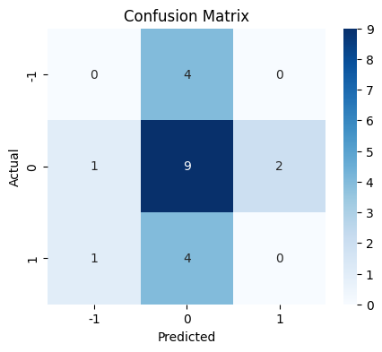

```python
plot_confusion_matrix(base_wv_gb,X_val_wv,y_val)
```

```python
# Calculate different metrics on training data
base_train_wv_gb = model_performance_classification_sklearn(base_wv_gb,X_train_wv,y_train)
print("Training performance:\n", base_train_wv_gb)
```

```
Training performance:
    Accuracy  Recall  Precision   F1
0       1.0     1.0        1.0  1.0
```

```python
# Calculate different metrics on validation data
base_val_wv_gb = model_performance_classification_sklearn(base_wv_gb,X_val_wv,y_val)
print("Validation performance:\n",base_val_wv_gb)
```

```
Validation performance:
    Accuracy    Recall  Precision       F1
0  0.428571  0.428571   0.302521  0.35468
```

**- Use the Classification report to look at the metrics**

```python
# Predicting on train data
y_pred_train = base_wv_gb.predict(X_train_wv)

# Predicting on validation data
y_pred_valid = base_wv_gb.predict(X_val_wv)
```

```python
# Classification report train
print(classification_report(y_train, y_pred_train))
```

```
              precision    recall  f1-score   support

          -1       1.00      1.00      1.00        82
           0       1.00      1.00      1.00       138
           1       1.00      1.00      1.00        66

    accuracy                           1.00       286
   macro avg       1.00      1.00      1.00       286
weighted avg       1.00      1.00      1.00       286
```

```python
# Classification report val
print(classification_report(y_val, y_pred_valid))
```

```
              precision    recall  f1-score   support

          -1       0.00      0.00      0.00         4
           0       0.53      0.75      0.62        12
           1       0.00      0.00      0.00         5

    accuracy                           0.43        21
   macro avg       0.18      0.25      0.21        21
weighted avg       0.30      0.43      0.35        21
```

- The model achieved a 43% recall score on the validation dataset.
- However, it failed to identify the negative and positive sentiments correctly.
- This might be due to the high imbalance of the target classes.
- The model is overfitting.

### Base Model - Word2Vec - Random Forest

```python
# Building the model

#base_wv = GradientBoostingClassifier(random_state = 42)
base_wv_rf = RandomForestClassifier(random_state=42)
#base_wv = DecisionTreeClassifier(random_state=42)

# Fitting on train data
base_wv_rf.fit(X_train_wv, y_train)
```

```
RandomForestClassifier(random_state=42)
```

```python
plot_confusion_matrix(base_wv_rf,X_train_wv,y_train)
```

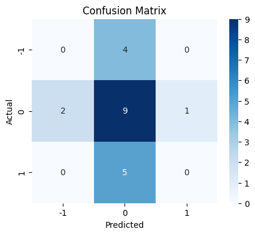

```python
plot_confusion_matrix(base_wv_rf,X_val_wv,y_val)
```

```python
# Calculate different metrics on training data
base_train_wv_rf = model_performance_classification_sklearn(base_wv_rf,X_train_wv,y_train)
print("Training performance:\n", base_train_wv_rf)
```

```
Training performance:
    Accuracy  Recall  Precision   F1
0       1.0     1.0        1.0  1.0
```

```python
# Calculate different metrics on validation data
base_val_wv_rf = model_performance_classification_sklearn(base_wv_rf,X_val_wv,y_val)
print("Validation performance:\n",base_val_wv_rf)
```

```
Validation performance:
    Accuracy    Recall  Precision        F1
0  0.428571  0.428571   0.285714  0.342857
```

- The Recall on this model is 43%.
- This model is overfitting.

### Base Model - Word2Vec - Decision Tree

```python
# Building the model

#base_wv = GradientBoostingClassifier(random_state = 42)
#base_wv = RandomForestClassifier(random_state=42)
base_wv_dt = DecisionTreeClassifier(random_state=42)

# Fitting on train data
base_wv_dt.fit(X_train_wv, y_train)
```

```
DecisionTreeClassifier(random_state=42)
```

```python
plot_confusion_matrix(base_wv_dt,X_train_wv,y_train)
```

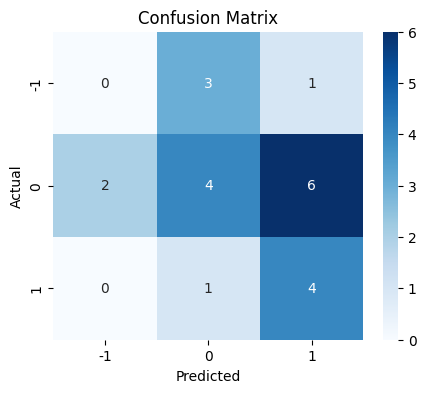

```python
plot_confusion_matrix(base_wv_dt,X_val_wv,y_val)
```

```python
# Calculate different metrics on training data
base_train_wv_dt = model_performance_classification_sklearn(base_wv_dt,X_train_wv,y_train)
print("Training performance:\n", base_train_wv_dt)
```

```
Training performance:
    Accuracy  Recall  Precision   F1
0       1.0     1.0        1.0  1.0
```

```python
# Calculate different metrics on validation data
base_val_wv_dt = model_performance_classification_sklearn(base_wv_dt,X_val_wv,y_val)
print("Validation performance:\n",base_val_wv_dt)
```

```
Validation performance:
    Accuracy    Recall  Precision        F1
0  0.380952  0.380952   0.372294  0.347619
```

**From this Word2Vec group, I will choose the Base Model - Word2Vec - Gradient Boosting model to tune, as it is the best of these three even though it is grossly overfitting. We will start with adding the "sample_weight" parameter to try to see how the class imbalance affects the outcome.**

### Base Model - Word2Vec - Gradient Boosting - Balanced

```python
# Building the model

base_wv_gb_balanced = GradientBoostingClassifier(random_state = 42)
#base_wv = RandomForestClassifier(random_state=42)
#base_wv = DecisionTreeClassifier(random_state=42)

# Calculate sample weights if needed to address class imbalance
from sklearn.utils.class_weight import compute_sample_weight
sample_weights = compute_sample_weight("balanced", y_train)

# Fitting on train data
#base_wv.fit(X_train_wv, y_train)
base_wv_gb_balanced.fit(X_train_wv, y_train, sample_weight=sample_weights)
```

```
GradientBoostingClassifier(random_state=42)
```

```python
plot_confusion_matrix(base_wv_gb_balanced,X_train_wv,y_train)
```

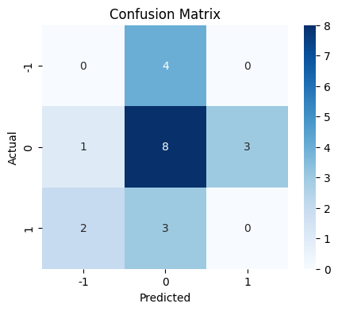

```python
plot_confusion_matrix(base_wv_gb_balanced,X_val_wv,y_val)
```

```python
# Calculate different metrics on training data
base_train_wv_gb_balanced = model_performance_classification_sklearn(base_wv_gb_balanced,X_train_wv,y_train)
print("Training performance:\n", base_train_wv_gb_balanced)
```

```
Training performance:
    Accuracy  Recall  Precision   F1
0       1.0     1.0        1.0  1.0
```

```python
# Calculate different metrics on validation data
base_val_wv_gb_balanced = model_performance_classification_sklearn(base_wv_gb_balanced,X_val_wv,y_val)
print("Validation performance:\n",base_val_wv_gb_balanced)
```

```
Validation performance:
    Accuracy    Recall  Precision        F1
0  0.380952  0.380952   0.304762  0.338624
```

**- Use the Classification report to look at the metrics**

```python
# Predicting on train data
y_pred_train = base_wv_gb_balanced.predict(X_train_wv)

# Predicting on validation data
y_pred_valid = base_wv_gb_balanced.predict(X_val_wv)
```

```python
# Classification report train
print(classification_report(y_train, y_pred_train))
```

```
              precision    recall  f1-score   support

          -1       1.00      1.00      1.00        82
           0       1.00      1.00      1.00       138
           1       1.00      1.00      1.00        66

    accuracy                           1.00       286
   macro avg       1.00      1.00      1.00       286
weighted avg       1.00      1.00      1.00       286
```

```python
# Classification report val
print(classification_report(y_val, y_pred_valid))
```

```
              precision    recall  f1-score   support

          -1       0.00      0.00      0.00         4
           0       0.53      0.67      0.59        12
           1       0.00      0.00      0.00         5

    accuracy                           0.38        21
   macro avg       0.18      0.22      0.20        21
weighted avg       0.30      0.38      0.34        21
```

- The model still achieved a 38% recall score on the validation dataset. So, there is a degradation on Recall even With the addition of the balancing parameter.
- However, it still failed to identify the negative and postitive sentiments correctly.
- The model is overfitting.

### Base Model - GloVe - Gradient Boosting

```python
# Build the model
base_gl_gb = GradientBoostingClassifier(random_state = 42)
#base_gl = RandomForestClassifier(random_state=42)
#base_gl = DecisionTreeClassifier(random_state=42)

# Fitting on train data
base_gl_gb.fit(X_train_gl, y_train)
```

```
GradientBoostingClassifier(random_state=42)
```

```python
plot_confusion_matrix(base_gl_gb,X_train_gl,y_train)
```

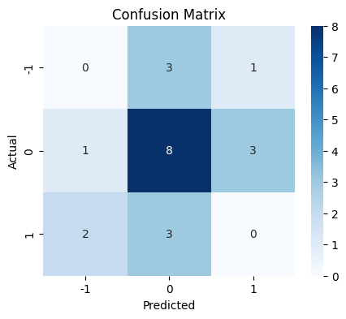

```python
plot_confusion_matrix(base_gl_gb,X_val_gl,y_val)
```

```python
# Calculate different metrics on training data
base_train_gl_gb = model_performance_classification_sklearn(base_gl_gb,X_train_gl,y_train)
print("Training performance:\n", base_train_gl_gb)
```

```
Training performance:
    Accuracy  Recall  Precision   F1
0       1.0     1.0        1.0  1.0
```

```python
# Calculate different metrics on validation data
base_val_gl_gb = model_performance_classification_sklearn(base_gl_gb,X_val_gl,y_val)
print("Validation performance:\n",base_val_gl_gb)
```

```
Validation performance:
    Accuracy    Recall  Precision        F1
0  0.380952  0.380952   0.326531  0.351648
```

- This model is overfitting.
- Recall on validation data set is 38%. The accuracy is the same.

### Base Model - GloVe - Random Forest

```python
# Build the model

#base_gl = GradientBoostingClassifier(random_state = 42)
base_gl_rf = RandomForestClassifier(random_state=42)
#base_gl = DecisionTreeClassifier(random_state=42)

# Fitting on train data
base_gl_rf.fit(X_train_gl, y_train)
```

```
RandomForestClassifier(random_state=42)
```

```python
plot_confusion_matrix(base_gl_rf,X_train_gl,y_train)
```

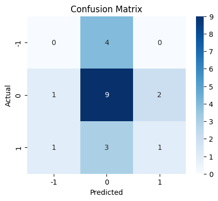

```python
plot_confusion_matrix(base_gl_rf,X_val_gl,y_val)
```

```python
# Calculate different metrics on training data
base_train_gl_rf=model_performance_classification_sklearn(base_gl_rf,X_train_gl,y_train)
print("Training performance:\n", base_train_gl_rf)
```

```
Training performance:
    Accuracy  Recall  Precision   F1
0       1.0     1.0        1.0  1.0
```

```python
# Calculate different metrics on validation data
base_val_gl_rf = model_performance_classification_sklearn(base_gl_rf,X_val_gl,y_val)
print("Validation performance:\n",base_val_gl_rf)
```

```
Validation performance:
    Accuracy   Recall  Precision        F1
0   0.47619  0.47619   0.400794  0.426871
```

**- Use the Classification report to look at the metrics**

```python
# Predicting on train data
y_pred_train = base_gl_rf.predict(X_train_gl)

# Predicting on validation data
y_pred_valid = base_gl_rf.predict(X_val_gl)
```

```python
# Classification report train
print(classification_report(y_train, y_pred_train))
```

```
              precision    recall  f1-score   support

          -1       1.00      1.00      1.00        82
           0       1.00      1.00      1.00       138
           1       1.00      1.00      1.00        66

    accuracy                           1.00       286
   macro avg       1.00      1.00      1.00       286
weighted avg       1.00      1.00      1.00       286
```

```python
# Classification report val
print(classification_report(y_val, y_pred_valid))
```

```
              precision    recall  f1-score   support

          -1       0.00      0.00      0.00         4
           0       0.56      0.75      0.64        12
           1       0.33      0.20      0.25         5

    accuracy                           0.48        21
   macro avg       0.30      0.32      0.30        21
weighted avg       0.40      0.48      0.43        21
```

- The model achieved a 48% recall score on the validation dataset.
- However, this model failed to identify any of the negative sentiments correctly. It might be due to the class imbalance.
- The model is overfitting.

### Base Model - GloVe - Decision Tree

```python
# Build the model

#base_gl = GradientBoostingClassifier(random_state = 42)
#base_gl = RandomForestClassifier(random_state=42)
base_gl_dt = DecisionTreeClassifier(random_state=42)

# Fitting on train data
base_gl_dt.fit(X_train_gl, y_train)
```

```
DecisionTreeClassifier(random_state=42)
```

```python
plot_confusion_matrix(base_gl_dt,X_train_gl,y_train)
```

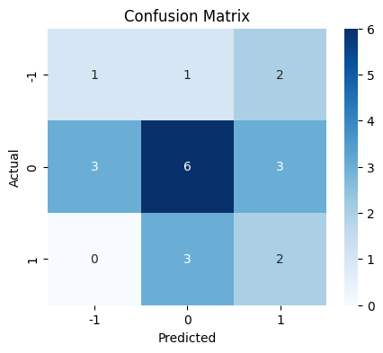

```python
plot_confusion_matrix(base_gl_dt,X_val_gl,y_val)
```

```python
# Calculate different metrics on training data
base_train_gl_dt=model_performance_classification_sklearn(base_gl_dt,X_train_gl,y_train)
print("Training performance:\n", base_train_gl_dt)
```

```
Training performance:
    Accuracy  Recall  Precision   F1
0       1.0     1.0        1.0  1.0
```

```python
# Calculate different metrics on validation data
base_val_gl_dt = model_performance_classification_sklearn(base_gl_dt,X_val_gl,y_val)
print("Validation performance:\n",base_val_gl_dt)
```

```
Validation performance:
    Accuracy    Recall  Precision        F1
0  0.428571  0.428571   0.458503  0.438672
```

- This model is overfitting.
- Recall on validation data set is 43%. The accuracy is the same.

**From this GloVe group, I will choose the Base Model - GloVe - Random Forest model to tune, as it is the best of these three even though it is grossly overfitting. We will start with adding the "class_weight" parameter to try to see how the class imbalance affects the outcome.**

### Base Model - GloVe - Random Forest - Balanced

```python
# Build the model

#base_gl = GradientBoostingClassifier(random_state = 42)
base_gl_rf_balanced = RandomForestClassifier(class_weight = "balanced", random_state=42)
#base_gl = DecisionTreeClassifier(random_state=42)

# Fitting on train data
base_gl_rf_balanced.fit(X_train_gl, y_train)
```

```
RandomForestClassifier(class_weight='balanced', random_state=42)
```

```python
plot_confusion_matrix(base_gl_rf_balanced,X_train_gl,y_train)
```

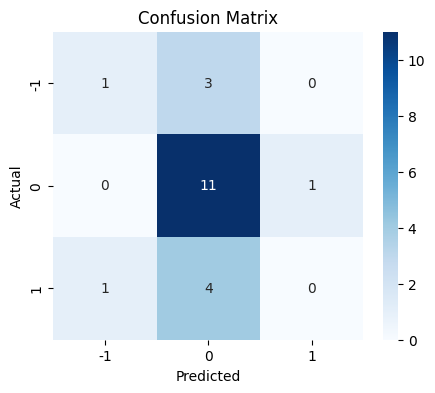

```python
plot_confusion_matrix(base_gl_rf_balanced,X_val_gl,y_val)
```

```python
# Calculate different metrics on training data
base_train_gl_rf_balanced=model_performance_classification_sklearn(base_gl_rf_balanced,X_train_gl,y_train)
print("Training performance:\n", base_train_gl_rf_balanced)
```

```
Training performance:
    Accuracy  Recall  Precision   F1
0       1.0     1.0        1.0  1.0
```

```python
# Calculate different metrics on validation data
base_val_gl_rf_balanced = model_performance_classification_sklearn(base_gl_rf_balanced,X_val_gl,y_val)
print("Validation performance:\n",base_val_gl_rf_balanced)
```

```
Validation performance:
    Accuracy    Recall  Precision       F1
0  0.571429  0.571429   0.444444  0.48254
```

**- Use the Classification report to look at the metrics**

```python
# Predicting on train data
y_pred_train = base_gl_rf_balanced.predict(X_train_gl)

# Predicting on validation data
y_pred_valid = base_gl_rf_balanced.predict(X_val_gl)
```

```python
# Classification report train
print(classification_report(y_train, y_pred_train))
```

```
              precision    recall  f1-score   support

          -1       1.00      1.00      1.00        82
           0       1.00      1.00      1.00       138
           1       1.00      1.00      1.00        66

    accuracy                           1.00       286
   macro avg       1.00      1.00      1.00       286
weighted avg       1.00      1.00      1.00       286
```

```python
# Classification report val
print(classification_report(y_val, y_pred_valid))
```

```
              precision    recall  f1-score   support

          -1       0.50      0.25      0.33         4
           0       0.61      0.92      0.73        12
           1       0.00      0.00      0.00         5

    accuracy                           0.57        21
   macro avg       0.37      0.39      0.36        21
weighted avg       0.44      0.57      0.48        21
```

### Base Model - Sentence Transformer - Gradient Boosting

```python
# Build the model

base_st_gb = GradientBoostingClassifier(random_state = 42)
#base_st = RandomForestClassifier(random_state=42)
#base_st = DecisionTreeClassifier(random_state=42)

# Fitting on train data
base_st_gb.fit(X_train_st, y_train)
```

```
GradientBoostingClassifier(random_state=42)
```

```python
plot_confusion_matrix(base_st_gb,X_train_st,y_train)
```

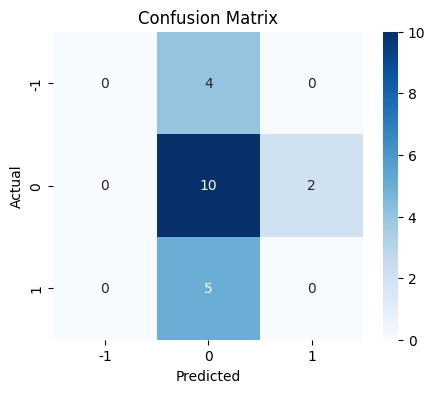

```python
plot_confusion_matrix(base_st_gb,X_val_st,y_val)
```

```python
# Calculate different metrics on training data
base_train_st_gb=model_performance_classification_sklearn(base_st_gb,X_train_st,y_train)
print("Training performance:\n", base_train_st_gb)
```

```
Training performance:
    Accuracy  Recall  Precision   F1
0       1.0     1.0        1.0  1.0
```

```python
# Calculate different metrics on validation data
base_val_st_gb = model_performance_classification_sklearn(base_st_gb,X_val_st,y_val)
print("Validation performance:\n",base_val_st_gb)
```

```
Validation performance:
    Accuracy   Recall  Precision        F1
0   0.47619  0.47619   0.300752  0.368664
```

- Recall and accuracy are both 48%.
- The model is overfitting.

### Base Model - Sentence Transformer - Random Forest

```python
# Build the model

#base_st = GradientBoostingClassifier(random_state = 42)
base_st_rf = RandomForestClassifier(random_state=42)
#base_st = DecisionTreeClassifier(random_state=42)

# Fitting on train data
base_st_rf.fit(X_train_st, y_train)
```

```
RandomForestClassifier(random_state=42)
```

```python
plot_confusion_matrix(base_st_rf,X_train_st,y_train)
```

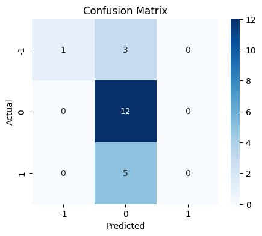

```python
plot_confusion_matrix(base_st_rf,X_val_st,y_val)
```

```python
# Calculate different metrics on training data
base_train_st_rf=model_performance_classification_sklearn(base_st_rf,X_train_st,y_train)
print("Training performance:\n", base_train_st_rf)
```

```
Training performance:
    Accuracy  Recall  Precision   F1
0       1.0     1.0        1.0  1.0
```

```python
# Calculate different metrics on validation data
base_val_st_rf = model_performance_classification_sklearn(base_st_rf,X_val_st,y_val)
print("Validation performance:\n",base_val_st_rf)
```

```
Validation performance:
    Accuracy    Recall  Precision        F1
0  0.619048  0.619048   0.533333  0.504762
```

**- Use the Classification report to look at the metrics**

```python
# Predicting on train data
y_pred_train = base_st_rf.predict(X_train_st)

# Predicting on validation data
y_pred_valid = base_st_rf.predict(X_val_st)
```

```python
# Classification report train
print(classification_report(y_train, y_pred_train))
```

```
              precision    recall  f1-score   support

          -1       1.00      1.00      1.00        82
           0       1.00      1.00      1.00       138
           1       1.00      1.00      1.00        66

    accuracy                           1.00       286
   macro avg       1.00      1.00      1.00       286
weighted avg       1.00      1.00      1.00       286
```

```python
# Classification report val
print(classification_report(y_val, y_pred_valid))
```

```
              precision    recall  f1-score   support

          -1       1.00      0.25      0.40         4
           0       0.60      1.00      0.75        12
           1       0.00      0.00      0.00         5

    accuracy                           0.62        21
   macro avg       0.53      0.42      0.38        21
weighted avg       0.53      0.62      0.50        21
```

- This is our best model so far with a Recall and Accuracy of 62% on the validation data set.
- However, this model failed to identify any of the positive sentiments correctly. It might be due to the class imbalance.
- The model is overfitting.
- We will use this model.
- This is our best model so far with a Recall and Accuracy of 62%.
- It is still overfitting.
- We will use this model.

### Base Model - Sentence Transformer - Decision Tree

```python
# Build the model

#base_st = GradientBoostingClassifier(random_state = 42)
#base_st = RandomForestClassifier(random_state=42)
base_st_dt = DecisionTreeClassifier(random_state=42)

# Fitting on train data
base_st_dt.fit(X_train_st, y_train)
```

```
DecisionTreeClassifier(random_state=42)
```

```python
plot_confusion_matrix(base_st_dt,X_train_st,y_train)
```

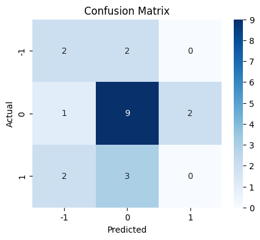

```python
plot_confusion_matrix(base_st_dt,X_val_st,y_val)
```

```python
# Calculate different metrics on training data
base_train_st_dt=model_performance_classification_sklearn(base_st_dt,X_train_st,y_train)
print("Training performance:\n", base_train_st_dt)
```

```
Training performance:
    Accuracy  Recall  Precision   F1
0       1.0     1.0        1.0  1.0
```

```python
# Calculate different metrics on validation data
base_val_st_dt = model_performance_classification_sklearn(base_st_dt,X_val_st,y_val)
print("Validation performance:\n",base_val_st_dt)
```

```
Validation performance:
    Accuracy   Recall  Precision       F1
0   0.52381  0.52381   0.443537  0.48026
```

**- From this Sentence Transformer group, I will choose the Base Model - Sentence Transformer - Random Forest model to tune, as it is the best of these three even though it is overfitting. We will start with adding the "class_weight" parameter to try to see how the class imbalance affects the outcome.**

### Base Model - Sentence Transformer - Random Forest - Balanced

```python
# Build the model

#base_st = GradientBoostingClassifier(random_state = 42)
base_st_rf_balanced = RandomForestClassifier(class_weight = "balanced", random_state=42)
#base_st = DecisionTreeClassifier(random_state=42)

# Fitting on train data
base_st_rf_balanced.fit(X_train_st, y_train)
```

```
RandomForestClassifier(class_weight='balanced', random_state=42)
```

```python
plot_confusion_matrix(base_st_rf_balanced,X_train_st,y_train)
```

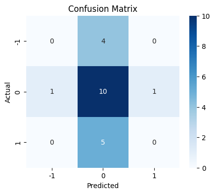

```python
plot_confusion_matrix(base_st_rf_balanced,X_val_st,y_val)
```

```python
# Calculate different metrics on training data
base_train_st_rf_balanced=model_performance_classification_sklearn(base_st_rf_balanced,X_train_st,y_train)
print("Training performance:\n", base_train_st_rf_balanced)
```

```
Training performance:
    Accuracy  Recall  Precision   F1
0       1.0     1.0        1.0  1.0
```

```python
# Calculate different metrics on validation data
base_val_st_rf_balanced = model_performance_classification_sklearn(base_st_rf_balanced,X_val_st,y_val)
print("Validation performance:\n",base_val_st_rf_balanced)
```

```
Validation performance:
    Accuracy   Recall  Precision        F1
0   0.47619  0.47619   0.300752  0.368664
```

**- Use the Classification report to look at the metrics**

```python
# Predicting on train data
y_pred_train = base_st_rf_balanced.predict(X_train_st)

# Predicting on validation data
y_pred_valid = base_st_rf_balanced.predict(X_val_st)
```

```python
# Classification report train
print(classification_report(y_train, y_pred_train))
```

```
              precision    recall  f1-score   support

          -1       1.00      1.00      1.00        82
           0       1.00      1.00      1.00       138
           1       1.00      1.00      1.00        66

    accuracy                           1.00       286
   macro avg       1.00      1.00      1.00       286
weighted avg       1.00      1.00      1.00       286
```

```python
# Classification report val
print(classification_report(y_val, y_pred_valid))
```

```
              precision    recall  f1-score   support

          -1       0.00      0.00      0.00         4
           0       0.53      0.83      0.65        12
           1       0.00      0.00      0.00         5

    accuracy                           0.48        21
   macro avg       0.18      0.28      0.22        21
weighted avg       0.30      0.48      0.37        21
```

### Tuned Model - Word2Vec

**Note**: The parameter grid provided below is a sample grid. It can be modified depending on the compute power of the system being used.

```python
start = time.time()

# Choose the type of classifier.

tuned_wv = GradientBoostingClassifier(random_state = 42)
#tuned_wv = RandomForestClassifier(random_state=42)
#tuned_wv = DecisionTreeClassifier(random_state=42)


parameters = {
    'max_depth': np.arange(3,7),
    'min_samples_split': np.arange(5,12,2),
    'max_features': ['log2', 'sqrt', 0.2, 0.4]
}

# Run the grid search
grid_obj = GridSearchCV(tuned_wv, parameters, scoring='f1_weighted',cv=5,n_jobs=-1)
grid_obj = grid_obj.fit(X_train_wv, y_train)

end = time.time()
print("Time taken ",(end-start))

# Set the clf to the best combination of parameters
tuned_wv = grid_obj.best_estimator_
```

```
Time taken  335.56950879096985
```

```python
# Fit the best algorithm to the data.
tuned_wv.fit(X_train_wv, y_train)
```

```
GradientBoostingClassifier(max_depth=4, max_features=0.2, min_samples_split=7,
                           random_state=42)
```

```python
plot_confusion_matrix(tuned_wv,X_train_wv,y_train)
```

[output not shown]

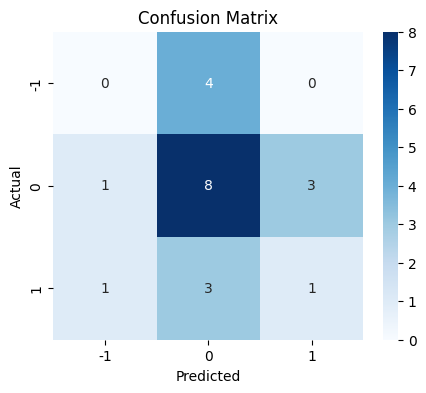

```python
plot_confusion_matrix(tuned_wv,X_val_wv,y_val)
```

```python
#Calculating different metrics on training data
tuned_train_wv=model_performance_classification_sklearn(tuned_wv,X_train_wv,y_train)
print("Training performance:\n",tuned_train_wv)
```

```
Training performance:
    Accuracy  Recall  Precision   F1
0       1.0     1.0        1.0  1.0
```

```python
#Calculating different metrics on validation data
tuned_val_wv = model_performance_classification_sklearn(tuned_wv,X_val_wv,y_val)
print("Validation performance:\n",tuned_val_wv)
```

```
Validation performance:
    Accuracy    Recall  Precision        F1
0  0.428571  0.428571   0.364286  0.391534
```

- The Recall score is 43% on the validation data set. No improvement with this tuned model
- This model is overfitting.

### Tuned Model - GloVe

```python
start = time.time()

#tuned_wv = GradientBoostingClassifier(random_state = 42)
tuned_wv = RandomForestClassifier(random_state=42)
#tuned_wv = DecisionTreeClassifier(random_state=42)

parameters = {
    'max_depth': np.arange(3,7),
    'min_samples_split': np.arange(5,12,2),
    'max_features': ['log2', 'sqrt', 0.2, 0.4]
}

# Run the grid search
grid_obj = GridSearchCV(tuned_wv, parameters, scoring='f1_weighted',cv=5,n_jobs=-1)
grid_obj = grid_obj.fit(X_train_gl, y_train)

end = time.time()
print("Time taken ",(end-start))

# Set the clf to the best combination of parameters
tuned_gl = grid_obj.best_estimator_
```

```
Time taken  53.75439214706421
```

```python
# Fit the best algorithm to the data.
tuned_gl.fit(X_train_gl, y_train)
```

```
RandomForestClassifier(max_depth=6, max_features=0.2, min_samples_split=7,
                       random_state=42)
```

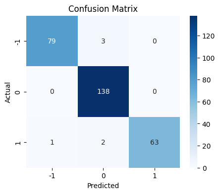

```python
plot_confusion_matrix(tuned_gl,X_train_gl,y_train)
```

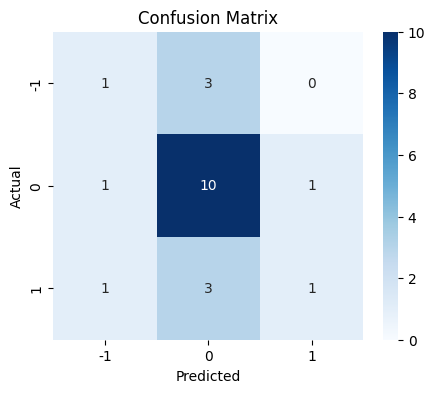

```python
plot_confusion_matrix(tuned_gl,X_val_gl,y_val)
```

```python
# Calculate different metrics on training data
tuned_train_gl=model_performance_classification_sklearn(tuned_gl,X_train_gl,y_train)
print("Training performance:\n",tuned_train_gl)
```

```
Training performance:
    Accuracy    Recall  Precision        F1
0  0.979021  0.979021   0.979545  0.978968
```

```python
# Calculate different metrics on validation data
tuned_val_gl = model_performance_classification_sklearn(tuned_gl,X_val_gl,y_val)
print("Validation performance:\n",tuned_val_gl)
```

```
Validation performance:
    Accuracy    Recall  Precision        F1
0  0.571429  0.571429   0.539683  0.530612
```

- This tuned model performed better than the previously tuned model with a Recall score of 57% but is still overfitting.

### Tuned Model - Sentence Transformer

```python
start = time.time()

# Choose the type of classifier.

#tuned_wv = GradientBoostingClassifier(random_state = 42)
tuned_wv = RandomForestClassifier(random_state=42)
#tuned_wv = DecisionTreeClassifier(random_state=42)

parameters = {
    'max_depth': np.arange(3,7),
    'min_samples_split': np.arange(5,12,2),
    'max_features': ['log2', 'sqrt', 0.2, 0.4]
}

# Run the grid search
grid_obj = GridSearchCV(tuned_wv, parameters, scoring='f1_weighted',cv=5,n_jobs=-1)
grid_obj = grid_obj.fit(X_train_st, y_train)

end = time.time()
print("Time taken ",(end-start))

# Set the clf to the best combination of parameters
tuned_st = grid_obj.best_estimator_
```

```
Time taken  105.5523099899292
```

```python
# Fit the best algorithm to the data.
tuned_st.fit(X_train_st, y_train)
```

```
RandomForestClassifier(max_depth=6, max_features=0.2, min_samples_split=11,
                       random_state=42)
```

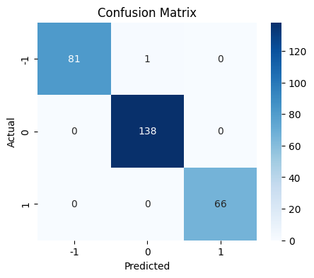

```python
plot_confusion_matrix(tuned_st,X_train_st,y_train)
```

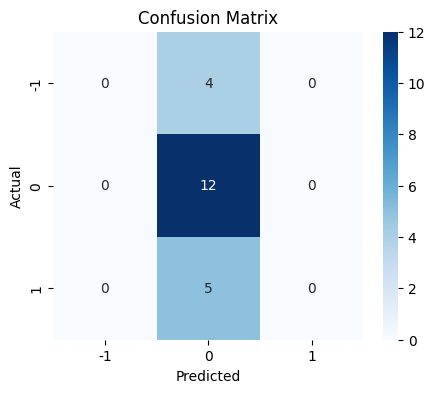

```python
plot_confusion_matrix(tuned_st,X_val_st,y_val)
```

```python
#Calculating different metrics on training data
tuned_train_st=model_performance_classification_sklearn(tuned_st,X_train_st,y_train)
print("Training performance:\n",tuned_train_st)
```

```
Training performance:
    Accuracy    Recall  Precision        F1
0  0.996503  0.996503   0.996529  0.996499
```

```python
#Calculating different metrics on validation data
tuned_val_st = model_performance_classification_sklearn(tuned_st,X_val_st,y_val)
print("Validation performance:\n",tuned_val_st)
```

```
Validation performance:
    Accuracy    Recall  Precision        F1
0  0.571429  0.571429   0.326531  0.415584
```

### Model Performance Summary and Final Model Selection

```python
#training performance comparison

models_train_comp_df = pd.concat(
    [base_train_wv_gb.T,
     base_train_gl_rf_balanced.T,
     base_train_st_rf.T,
     tuned_train_wv.T,
     tuned_train_gl.T,
     tuned_train_st.T,
    ],axis=1
)

models_train_comp_df.columns = [
    "Base Model (Word2Vec)",
    "Base Model (GloVe)",
    "Base Model (Sentence Transformer)",
    "Tuned Model (Word2Vec)",
    "Tuned Model (GloVe)",
    "Tuned Model (Sentence Transformer)",
]

print("Training performance comparison:")
models_train_comp_df
```

```
Training performance comparison:
```

|  | Base Model (Word2Vec) | Base Model (GloVe) | Base Model (Sentence Transformer) | Tuned Model (Word2Vec) | Tuned Model (GloVe) | Tuned Model (Sentence Transformer) |
| --- | --- | --- | --- | --- | --- | --- |
| Accuracy | 1.0 | 1.0 | 1.0 | 1.0 | 0.979021 | 0.996503 |
| Recall | 1.0 | 1.0 | 1.0 | 1.0 | 0.979021 | 0.996503 |
| Precision | 1.0 | 1.0 | 1.0 | 1.0 | 0.979545 | 0.996529 |
| F1 | 1.0 | 1.0 | 1.0 | 1.0 | 0.978968 | 0.996499 |

```python
#validation performance comparison

models_val_comp_df = pd.concat(
    [base_val_wv_gb.T,
     base_val_gl_rf_balanced.T,
     base_val_st_rf.T,
     tuned_val_wv.T,
     tuned_val_gl.T,
     tuned_val_st.T,
     ],axis=1
)

models_val_comp_df.columns = [
    "Base Model (Word2Vec)",
    "Base Model (GloVe)",
    "Base Model (Sentence Transformer)",
    "Tuned Model (Word2Vec)",
    "Tuned Model (GloVe)",
    "Tuned Model (Sentence Transformer)",
]

print("Validation performance comparison:")
models_val_comp_df
```

```
Validation performance comparison:
```

|  | Base Model (Word2Vec) | Base Model (GloVe) | Base Model (Sentence Transformer) | Tuned Model (Word2Vec) | Tuned Model (GloVe) | Tuned Model (Sentence Transformer) |
| --- | --- | --- | --- | --- | --- | --- |
| Accuracy | 0.428571 | 0.571429 | 0.619048 | 0.428571 | 0.571429 | 0.571429 |
| Recall | 0.428571 | 0.571429 | 0.619048 | 0.428571 | 0.571429 | 0.571429 |
| Precision | 0.302521 | 0.444444 | 0.533333 | 0.364286 | 0.539683 | 0.326531 |
| F1 | 0.354680 | 0.482540 | 0.504762 | 0.391534 | 0.530612 | 0.415584 |

- The **Base Model (Sentence Transformer)** model has the best performance with Recall of 62% and Accuracy same. This is our final selected model.

### Model Performance Check on Test Data

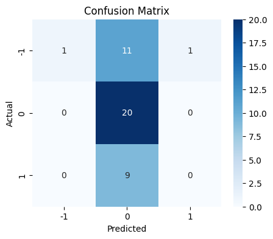

```python
plot_confusion_matrix(base_st_rf,X_test_st,y_test)
```

```python
# Calculate different metrics on training data
final_model_test = model_performance_classification_sklearn(base_st_rf,X_test_st,y_test)
print("Test performance for the final model:\n",final_model_test)
```

```
Test performance for the final model:
    Accuracy  Recall  Precision        F1
0       0.5     0.5   0.547619  0.361678
```

- The final model has a Recall of 50% on the test data. The accuracy is the same.
- While this is the best model here, I would say that the model is not production ready.

## **Weekly News Summarization**

**Important Note**: It is recommended to run this section of the project independently from the previous sections in order to avoid runtime crashes due to RAM overload.

#### Installing and Importing the necessary libraries

```python
# Installation for GPU llama-cpp-python
# uncomment and run the following code in case GPU is being used
#!CMAKE_ARGS="-DLLAMA_CUBLAS=on" FORCE_CMAKE=1 pip install llama-cpp-python -q

# Installation for CPU llama-cpp-python
# uncomment and run the following code in case GPU is not being used
#!CMAKE_ARGS="-DLLAMA_CUBLAS=off" FORCE_CMAKE=1 pip install llama-cpp-python -q
```

```python
import torch
torch.cuda.is_available()
```

```
True
```

```python
# Install necessary libraries
!apt-get install -y cmake python3-dev
!apt-get install -y libopenblas-dev
!pip install llama-cpp-python
```

```
Reading package lists... Done
Building dependency tree... Done
Reading state information... Done
cmake is already the newest version (3.22.1-1ubuntu1.22.04.2).
python3-dev is already the newest version (3.10.6-1~22.04.1).
0 upgraded, 0 newly installed, 0 to remove and 29 not upgraded.
Reading package lists... Done
Building dependency tree... Done
Reading state information... Done
libopenblas-dev is already the newest version (0.3.20+ds-1).
0 upgraded, 0 newly installed, 0 to remove and 29 not upgraded.
```

```python
!pip install huggingface_hub
from huggingface_hub import hf_hub_download
import pandas as pd
```

```python
# Function to download the model from the Hugging Face model hub
from huggingface_hub import hf_hub_download

# Importing the Llama class from the llama_cpp module
from llama_cpp import Llama

# Importing the library for data manipulation
import pandas as pd

from tqdm import tqdm # For progress bar related functionalities
tqdm.pandas()
```

#### Loading the data

```python
stock_news = pd.read_csv("/content/drive/MyDrive/Python Course/stock_news.csv")
```

```python
data = stock_news.copy()
```

#### Loading the model

```python
model_name_or_path = "TheBloke/Mistral-7B-Instruct-v0.2-GGUF"
model_basename = "mistral-7b-instruct-v0.2.Q6_K.gguf"


model_path = hf_hub_download(
    repo_id=model_name_or_path,
    filename=model_basename
)
```

```python
# uncomment the below snippet of code if the runtime is connected to GPU.
llm = Llama(
    model_path=model_path, # Path to the model
    n_gpu_layers=45, #Number of layers transferred to GPU
    n_ctx=4500, #Context window
)
```

[output not shown]

[output cut: 117 more lines]

[output not shown]

```python
# uncomment and run the following code in case GPU is not being used

# llm = Llama(
#     model_path=model_path,
#     n_ctx=4500, # Context window
#     n_cores=-2 # Number of CPU cores to use
# )
```

#### Aggregating the data weekly

```python
# Convert the 'Date' column to datetime format.
data["Date"] = pd.to_datetime(data['Date'])
```

```python
# Group the data by week using the 'Date' column.
weekly_grouped = data.groupby(pd.Grouper(key='Date', freq='W'))
```

```python
# Combine the data in eaach weekly group,, separating them with ||
weekly_grouped = weekly_grouped.agg(
    {
        'News': lambda x: ' || '.join(x)  # Join the news values with ' || ' separator.
    }
).reset_index()

print(weekly_grouped.shape)
```

```
(18, 2)
```

```python
weekly_grouped
```

|  | Date | News |
| --- | --- | --- |
| 0 | 2019-01-06 | The tech sector experienced a significant dec... |
| 1 | 2019-01-13 | Sprint and Samsung plan to release 5G smartph... |
| 2 | 2019-01-20 | The U.S. stock market declined on Monday as c... |
| 3 | 2019-01-27 | The Swiss National Bank (SNB) governor, Andre... |
| 4 | 2019-02-03 | Caterpillar Inc reported lower-than-expected ... |
| 5 | 2019-02-10 | The Dow Jones Industrial Average, S&P 500, an... |
| 6 | 2019-02-17 | This week, the European Union's second highes... |
| 7 | 2019-02-24 | This news article discusses progress towards ... |
| 8 | 2019-03-03 | The Dow Jones Industrial Average and other ma... |
| 9 | 2019-03-10 | Spotify, the world's largest paid music strea... |
| 10 | 2019-03-17 | The United States opposes France's digital se... |
| 11 | 2019-03-24 | Facebook's stock price dropped more than 3% o... |
| 12 | 2019-03-31 | This news article reports that the S&P 500 In... |
| 13 | 2019-04-07 | Apple and other consumer brands, including LV... |
| 14 | 2019-04-14 | In March, mobile phone shipments to China dro... |
| 15 | 2019-04-21 | The chairman of Taiwan's Foxconn, Terry Gou, ... |
| 16 | 2019-04-28 | Taiwan's export orders continued to decline f... |
| 17 | 2019-05-05 | Spotify reported better-than-expected Q1 reve... |

```python
# creating a copy of the data
data_1 = weekly_grouped.copy()
```

#### Summarization

##### Instructions

**Note**:

- The model is expected to summarize the news from the week by identifying the top three positive and negative events that are most likely to impact the price of the stock.
- As an output, the model is expected to return a JSON containing two keys, one for Positive Events and one for Negative Events.

For the project, we need to define the prompt to be fed to the LLM to help it understand the task to perform. The following should be the components of the prompt:

1. **Role**: Specifies the role the LLM will be taking up to perform the specified task, along with any specific details regarding the role
   - **Example**: `You are an expert data analyst specializing in news content analysis.`
2. **Task**: Specifies the task to be performed and outlines what needs to be accomplished, clearly defining the objective
   - **Example**: `Analyze the provided news headline and return the main topics contained within it.`
3. **Instructions**: Provides detailed guidelines on how to perform the task, which includes steps, rules, and criteria to ensure the task is executed correctly
   - **Example**:

```
Instructions:
1. Read the news headline carefully.
2. Identify the main subjects or entities mentioned in the headline.
3. Determine the key events or actions described in the headline.
4. Extract relevant keywords that represent the topics.
5. List the topics in a concise manner.
```

1. **Output Format**: Specifies the format in which the final response should be structured, ensuring consistency and clarity in the generated output
   - **Example**: `Return the output in JSON format with keys as the topic number and values as the actual topic.`

**Full Prompt Example**:

```
You are an expert data analyst specializing in news content analysis.

Task: Analyze the provided news headline and return the main topics contained within it.

Instructions:
1. Read the news headline carefully.
2. Identify the main subjects or entities mentioned in the headline.
3. Determine the key events or actions described in the headline.
4. Extract relevant keywords that represent the topics.
5. List the topics in a concise manner.

Return the output in JSON format with keys as the topic number and values as the actual topic.
```

**Sample Output**:

`{"1": "Politics", "2": "Economy", "3": "Health" }`

##### Utility Functions

```python
# defining a function to parse the JSON output from the model
def extract_json_data(json_str):
    import json
    try:
        # Find the indices of the opening and closing curly braces
        json_start = json_str.find('{')
        json_end = json_str.rfind('}')

        if json_start != -1 and json_end != -1:
            extracted_category = json_str[json_start:json_end + 1]  # Extract the JSON object
            data_dict = json.loads(extracted_category)
            return data_dict
        else:
            print(f"Warning: JSON object not found in response: {json_str}")
            return {}
    except json.JSONDecodeError as e:
        print(f"Error parsing JSON: {e}")
        return {}
```

##### Defining the response function

```python
# Define the response function
def response_mistral_1(prompt, news):
    model_output = llm(
      f"""
      [INST]
      {prompt}
      News Articles: {news}
      [/INST]
      """,
      max_tokens=1024, # Maximum number of tokens the model should generate for this task.
      temperature=0.01, # Value for temperature.
      top_p=0.95, # Value for top_p
      top_k=5, # Value for top_k
      echo=False,
    )

    final_output = model_output["choices"][0]["text"]

    return final_output
```

##### Checking the model output on a sample

````python
# Define the prompt for this task
prompt = """
You are an expert financial analyst specializing in news impact on stock prices.

Task: Analyze the news articles from the past week and summarize the top three positive and top three negative events that are most likely to impact the stock price.

Instructions:
1. Carefully read the news articles provided for the week.
2. Identify events that are likely to positively influence the stock price (e.g., strong earnings reports, new product launches, favorable market trends).
3. Identify events that are likely to negatively influence the stock price (e.g., poor earnings reports, legal issues, economic downturns).
4. Select the top three positive events and the top three negative events based on their potential impact on the stock price.
5. Summarize each event concisely and clearly.
6. Return the output in JSON format containing two keys:
   - "Positive Events": An array of the top three positive events.
   - "Negative Events": An array of the top three negative events.

Output Format Example:
```json
{
  "Positive Events": [
    "Record quarterly earnings reported, exceeding market expectations.",
    "New product launch received positive customer feedback.",
    "Strategic partnership announced, expected to increase market share."
  ],
  "Negative Events": [
    "CEO resignation leading to uncertainty in leadership.",
    "Legal dispute with a competitor impacting brand reputation.",
    "Supply chain disruptions affecting product availability."
  ]
}

Only return the JSON, do NOT return any other text or information.
"""
````

**Run the model on a single news article (to see how it works and how quickly it runs)**

```python
news_single = stock_news.loc[0, 'News']
print(len(news_single.split(' ')))
news_single
```

```
46
```

```
" The tech sector experienced a significant decline in the aftermarket following Apple's Q1 revenue warning. Notable suppliers, including Skyworks, Broadcom, Lumentum, Qorvo, and TSMC, saw their stocks drop in response to Apple's downward revision of its revenue expectations for the quarter, previou…
```

```python
%%time
summary = response_mistral_1(prompt, news_single)
print(summary)
```

```
Llama.generate: 361 prefix-match hit, remaining 100 prompt tokens to eval
llama_perf_context_print:        load time =   51220.92 ms
llama_perf_context_print: prompt eval time =   11592.22 ms /   100 tokens (  115.92 ms per token,     8.63 tokens per second)
llama_perf_context_print:        eval time =   19535.06 ms /    87 runs   (  224.54 ms per token,     4.45 tokens per second)
llama_perf_context_print:       total time =   31172.03 ms /   187 tokens
```

````
```json
{
  "Positive Events": [],
  "Negative Events": [
    "Apple's Q1 revenue warning causing significant decline in tech sector stocks.",
    "Notable tech suppliers negatively impacted by Apple's revenue revision.",
    "Potential for decreased demand for tech products due to Apple's revenue warning."
  ]
}
```
CPU times: user 2min 47s, sys: 104 ms, total: 2min 47s
Wall time: 31.2 s
````

```python
summary
summ = extract_json_data(summary)
pd.json_normalize(summ)
```

|  | Positive Events | Negative Events |
| --- | --- | --- |
| 0 | [] | [Apple's Q1 revenue warning causing significan... |

**Note**: Use this section to test out the prompt with one instance before using it for the entire weekly data.

```python
news = data_1.loc[0, 'News']
```

```python
print(len(news.split(' ')))
news
```

```
2611
```

```
' The tech sector experienced a significant decline in the aftermarket following Apple\'s Q1 revenue warning. Notable suppliers, including Skyworks, Broadcom, Lumentum, Qorvo, and TSMC, saw their stocks drop in response to Apple\'s downward revision of its revenue expectations for the quarter, previ…
```

```python
prompt
```

```
'\nYou are an expert financial analyst specializing in news impact on stock prices.\n\nTask: Analyze the news articles from the past week and summarize the top three positive and top three negative events that are most likely to impact the stock price.\n\nInstructions:  \n1. Carefully read the news …
```

```python
%%time
summary = response_mistral_1(prompt, news)
print(summary)
```

```
Llama.generate: 453 prefix-match hit, remaining 3675 prompt tokens to eval
llama_perf_context_print:        load time =   51220.92 ms
llama_perf_context_print: prompt eval time =  447343.84 ms /  3675 tokens (  121.73 ms per token,     8.22 tokens per second)
llama_perf_context_print:        eval time =   59132.88 ms /   214 runs   (  276.32 ms per token,     3.62 tokens per second)
llama_perf_context_print:       total time =  506611.17 ms /  3889 tokens
```

````
```json
{
  "Positive Events": [
    "Roku Inc announces plans to offer premium video channels on a subscription basis through its free streaming service, The Roku Channel.",
    "FDIC Chair expresses no concern over market volatility affecting the U.S banking system.",
    "U.S. and China to hold first face-to-face trade talks since agreeing to a 90-day truce in their trade war."
  ],
  "Negative Events": [
    "Apple cuts quarterly revenue forecast for the first time in over 15 years due to weak iPhone sales in China.",
    "Goldman analyst lowers price target for Apple, citing potential risks to the tech giant's 2019 numbers.",
    "Delta Air Lines lowers fourth-quarter revenue growth forecast to a range of 3% from the previous estimate of 3% to 5%."
  ]
}
```
CPU times: user 1h 1min 29s, sys: 2.84 s, total: 1h 1min 32s
Wall time: 8min 26s
````

##### Checking the model output on the weekly data

```python
%%time
data_1['Key Events'] = data_1['News'].progress_apply(lambda x: response_mistral_1(prompt,x))
```

[output not shown]

[output cut: 17 more lines]

[output not shown]

```
CPU times: user 6h 13min 47s, sys: 10.3 s, total: 6h 13min 57s
Wall time: 55min 24s
```

```python
data_1
```

[output not shown]

```python
data_1['Key Events'].head()
```

|  | Key Events |
| --- | --- |
| 0 | ```json\n{\n "Positive Events": [\n "Roku ... |
| 1 | {\n "Positive Events": [\n ... |
| 2 | ```json\n{\n "Positive Events": [\n "Dialo... |
| 3 | ```json\n{\n "Positive Events": [\n "IBM r... |
| 4 | ```json\n{\n "Positive Events": [\n "Apple... |

**dtype:** object

##### Formatting the model output

```python
data_1['model_response_parsed'] = data_1['Key Events'].apply(extract_json_data)
data_1.head()
```

|  | Date | News | Key Events | model_response_parsed |
| --- | --- | --- | --- | --- |
| 0 | 2019-01-06 | The tech sector experienced a significant dec... | ```json\n{\n "Positive Events": [\n "Roku ... | {'Positive Events': ['Roku Inc announces plans... |
| 1 | 2019-01-13 | Sprint and Samsung plan to release 5G smartph... | {\n "Positive Events": [\n ... | {'Positive Events': ['Sprint and Samsung plann... |
| 2 | 2019-01-20 | The U.S. stock market declined on Monday as c... | ```json\n{\n "Positive Events": [\n "Dialo... | {'Positive Events': ['Dialog Semiconductor rep... |
| 3 | 2019-01-27 | The Swiss National Bank (SNB) governor, Andre... | ```json\n{\n "Positive Events": [\n "IBM r... | {'Positive Events': ['IBM reported better-than... |
| 4 | 2019-02-03 | Caterpillar Inc reported lower-than-expected ... | ```json\n{\n "Positive Events": [\n "Apple... | {'Positive Events': ['Apple reported stronger-... |

```python
model_response_parsed = pd.json_normalize(data_1['model_response_parsed'])
model_response_parsed.head()
```

|  | Positive Events | Negative Events |
| --- | --- | --- |
| 0 | [Roku Inc announces plans to offer premium vid... | [Apple cuts quarterly revenue forecast for the... |
| 1 | [Sprint and Samsung planning 5G smartphone rel... | [Geely's forecasted flat sales for 2019 due to... |
| 2 | [Dialog Semiconductor reported resilient Q4 re... | [Global economic slowdown concerns intensified... |
| 3 | [IBM reported better-than-expected earnings an... | [Swiss National Bank governor emphasized the n... |
| 4 | [Apple reported stronger-than-expected earning... | [Caterpillar reported lower-than-expected four... |

```python
final_output = pd.concat([data_1.reset_index(drop=True),model_response_parsed],axis=1)
final_output.drop(['Key Events','model_response_parsed'], axis=1, inplace=True)
final_output.columns = ['Week End Date', 'News', 'Week Positive Events', 'Week Negative Events']

final_output.head()
```

|  | Week End Date | News | Week Positive Events | Week Negative Events |
| --- | --- | --- | --- | --- |
| 0 | 2019-01-06 | The tech sector experienced a significant dec... | [Roku Inc announces plans to offer premium vid... | [Apple cuts quarterly revenue forecast for the... |
| 1 | 2019-01-13 | Sprint and Samsung plan to release 5G smartph... | [Sprint and Samsung planning 5G smartphone rel... | [Geely's forecasted flat sales for 2019 due to... |
| 2 | 2019-01-20 | The U.S. stock market declined on Monday as c... | [Dialog Semiconductor reported resilient Q4 re... | [Global economic slowdown concerns intensified... |
| 3 | 2019-01-27 | The Swiss National Bank (SNB) governor, Andre... | [IBM reported better-than-expected earnings an... | [Swiss National Bank governor emphasized the n... |
| 4 | 2019-02-03 | Caterpillar Inc reported lower-than-expected ... | [Apple reported stronger-than-expected earning... | [Caterpillar reported lower-than-expected four... |

## **Conclusions and Recommendations**

- I built and validated a number of models for the task of predicting sentiments based on news articles using Word2Vec, GloVe vector embeddings and Sentence Transformer encodings.
- I selected a model - **Base Model (Sentence Transformer)** Random Forest model with the best performance of Recall and Accuracy of 62% and 50% on the validation and test data sets.
- While this was the best model, it doesn't appear to be production ready. I would recommend that it be further tuned to try to improve on the metrics until the desired performance is achieved before deploying to production.
- More data should be used for training, validating and testing of the model to improve on the performance of the model.
- I then went further to use a pre-trained LLM with a well-crafted prompt to analyze sentiments based on news articles related to stocks.
- The new articles were grouped in a weekly time frame and the LLM was used to extract the top three positive events and the top three negative events based on their potential impact on the stock price, summarizing each event concisely and clearly and returning the output in a JSON format.
- This sentiment analysis system will enable the investment startup company to leverage artificial intelligence to address the challenge of interpreting stock-related news and its impact on stock prices.
- It will also enable them gauge market sentiment, and summarizing the news at a weekly level to enhance the accuracy of their stock price predictions and optimize investment strategies, thereby empowering their financial analysts with actionable insights, leading to more informed investment decisions and improved client outcomes.
- The prompt could also attempt to be reworded/recrafted to deliver better responses, as well as, the prompt parameters can also be tweaked for more desirable results.

Power Ahead